# Netflix Case Study by Pavithran

# UNIQUE ATTRIBUTES

```python
#unique attributes in Director Column:
print("Unique Directors: ", df_final["director"].unique())
print("Total No of Directors: ", df_final["director"].nunique())
```

```
Unique Directors:  ['Kirsten Johnson' 'nan' 'Julien Leclercq' ... 'Majid Al Ansari'
 'Peter Hewitt' 'Mozez Singh']
Total No of Directors:  4994
```

```python
#unique attributes in Cast Column:
print("Unique Actors: ", df_final["cast"].unique())
print("Total No of Actors: ", df_final["cast"].nunique())
```

```
Unique Actors:  ['nan' 'Ama Qamata' 'Khosi Ngema' ... 'Malkeet Rauni' 'Anita Shabdish'
 'Chittaranjan Tripathy']
Total No of Actors:  36440
```

```python
#unique attributes in Listed_in Column:
print("Unique Genre: ", df_final["listed_in"].unique())
print("Total No of Genre: ", df_final["listed_in"].nunique())
```

```
Unique Genre:  ['Documentaries' 'International TV Shows' 'TV Dramas' 'TV Mysteries'
 'Crime TV Shows' 'TV Action & Adventure' 'Docuseries' 'Reality TV'
 'Romantic TV Shows' 'TV Comedies' 'TV Horror' 'Children & Family Movies'
 'Dramas' 'Independent Movies' 'International Movies' 'British TV Shows'
 'Comedies' 'Spanish-Language TV Shows' 'Thrillers' 'Romantic Movies'
 'Music & Musicals' 'Horror Movies' 'Sci-Fi & Fantasy' 'TV Thrillers'
 "Kids' TV" 'Action & Adventure' 'TV Sci-Fi & Fantasy' 'Classic Movies'
 'Anime Features' 'Sports Movies' 'Anime Series' 'Korean TV Shows'
 'Science & Nature TV' 'Teen TV Shows' 'Cult Movies' 'TV Shows'
 'Faith & Spirituality' 'LGBTQ Movies' 'Stand-Up Comedy' 'Movies'
 'Stand-Up Comedy & Talk Shows' 'Classic & Cult TV']
Total No of Genre:  42
```

```python
#unique attributes in Rating Column:
print("Unique Ratings: ", df_final["rating"].unique())
print("Total No of Ratings: ", df_final["rating"].nunique())
```

```
Unique Ratings:  ['PG-13' 'TV-MA' 'PG' 'TV-14' 'TV-PG' 'TV-Y' 'TV-Y7' 'R' 'TV-G' 'G'
 'NC-17' '74 min' '84 min' '66 min' 'NR' nan 'TV-Y7-FV' 'UR']
Total No of Ratings:  17
```

```python
#unique attributes in Country Column:
print("Unique Country: ", df_final["country"].unique())
print("Total No of Country: ", df_final["country"].nunique())
```

```
Unique Country:  ['United States' 'South Africa' 'nan' 'India' 'Ghana' 'Burkina Faso'
 'United Kingdom' 'Germany' 'Ethiopia' 'Czech Republic' 'Mexico' 'Turkey'
 'Australia' 'France' 'Finland' 'China' 'Canada' 'Japan' 'Nigeria' 'Spain'
 'Belgium' 'South Korea' 'Singapore' 'Italy' 'Romania' 'Argentina'
 'Venezuela' 'Hong Kong' 'Russia' '' 'Ireland' 'Nepal' 'New Zealand'
 'Brazil' 'Greece' 'Jordan' 'Colombia' 'Switzerland' 'Israel' 'Taiwan'
 'Bulgaria' 'Algeria' 'Poland' 'Saudi Arabia' 'Thailand' 'Indonesia'
 'Egypt' 'Denmark' 'Kuwait' 'Netherlands' 'Malaysia' 'Vietnam' 'Hungary'
 'Sweden' 'Lebanon' 'Syria' 'Philippines' 'Iceland' 'United Arab Emirates'
 'Norway' 'Qatar' 'Mauritius' 'Austria' 'Cameroon' 'Palestine' 'Uruguay'
 'United Kingdom,' 'Kenya' 'Chile' 'Luxembourg' 'Cambodia' 'Bangladesh'
 'Portugal' 'Cayman Islands' 'Senegal' 'Serbia' 'Malta' 'Namibia' 'Angola'
 'Peru' 'Mozambique' 'Cambodia,' 'Belarus' 'Zimbabwe' 'Puerto Rico'
 'Pakistan' 'Cyprus' 'Guatemala' 'Iraq' 'Malawi' 'Paraguay' 'Croatia'
 'Iran' 'West Germany' 'United States,' 'Albania' 'Georgia' 'Soviet Union'
 'Morocco' 'Slovakia' 'Ukraine' 'Bermuda' 'Ecuador' 'Armenia' 'Mongolia'
 'Bahamas' 'Sri Lanka' 'Latvia' 'Liechtenstein' 'Cuba' 'Nicaragua'
 'Poland,' 'Slovenia' 'Dominican Republic' 'Samoa' 'Azerbaijan' 'Botswana'
 'Vatican City' 'Jamaica' 'Kazakhstan' 'Lithuania' 'Afghanistan' 'Somalia'
 'Sudan' 'Panama' 'Uganda' 'East Germany' 'Montenegro']
Total No of Country:  128
```

```python
# There are 36440 Actors in the data Frame
df_final["cast"].nunique()
```

```
36440
```

```python
# To Avoid the missing Values we replace Nan with Unknown
df_final['cast'].replace(["nan"], ["Unknown Actor"], inplace = True)
df_final['director'].replace(["nan"], ["Unknown Directors"], inplace = True)
df_final['country'].replace(["nan"], [np.nan], inplace =True)
```

```python
df_final.head(5)
```

|  | show_id | type | title | date_added | release_year | rating | duration | description | director | cast | country | listed_in |
| --- | --- | --- | --- | --- | --- | --- | --- | --- | --- | --- | --- | --- |
| 0 | s1 | Movie | Dick Johnson Is Dead | September 25, 2021 | 2020 | PG-13 | 90 min | As her father nears the end of his life, filmm... | Kirsten Johnson | Unknown Actor | United States | Documentaries |
| 1 | s2 | TV Show | Blood & Water | September 24, 2021 | 2021 | TV-MA | 2 Seasons | After crossing paths at a party, a Cape Town t... | Unknown Directors | Ama Qamata | South Africa | International TV Shows |
| 2 | s2 | TV Show | Blood & Water | September 24, 2021 | 2021 | TV-MA | 2 Seasons | After crossing paths at a party, a Cape Town t... | Unknown Directors | Ama Qamata | South Africa | TV Dramas |
| 3 | s2 | TV Show | Blood & Water | September 24, 2021 | 2021 | TV-MA | 2 Seasons | After crossing paths at a party, a Cape Town t... | Unknown Directors | Ama Qamata | South Africa | TV Mysteries |
| 4 | s2 | TV Show | Blood & Water | September 24, 2021 | 2021 | TV-MA | 2 Seasons | After crossing paths at a party, a Cape Town t... | Unknown Directors | Khosi Ngema | South Africa | International TV Shows |

# REMOVING/FILLING NULL OR MISSING VALUES

```python
df_final.isnull().sum()
```

```
show_id             0
type                0
title               0
date_added        158
release_year        0
rating             67
duration            3
description         0
director            0
cast                0
country         11897
listed_in           0
dtype: int64
```

```python
#we found that there are three rows where the duration is typed in rating Column
df_final[df_final['duration'].isnull()]
```

|  | show_id | type | title | date_added | release_year | rating | duration | description | director | cast | country | listed_in |
| --- | --- | --- | --- | --- | --- | --- | --- | --- | --- | --- | --- | --- |
| 126537 | s5542 | Movie | Louis C.K. 2017 | April 4, 2017 | 2017 | 74 min | NaN | Louis C.K. muses on religion, eternal love, gi... | Louis C.K. | Louis C.K. | United States | Movies |
| 131603 | s5795 | Movie | Louis C.K.: Hilarious | September 16, 2016 | 2010 | 84 min | NaN | Emmy-winning comedy writer Louis C.K. brings h... | Louis C.K. | Louis C.K. | United States | Movies |
| 131737 | s5814 | Movie | Louis C.K.: Live at the Comedy Store | August 15, 2016 | 2015 | 66 min | NaN | The comic puts his trademark hilarious/thought... | Louis C.K. | Louis C.K. | United States | Movies |

```python
# we now changing the mistaken rating column to the duration
df_final.loc[df_final['duration'].isnull(), 'duration'] = df_final.loc[df_final['duration'].isnull(), 'duration'].fillna(df_final['rating'])
```

```python
df_final[df_final['duration'].isnull()]
```

|  | show_id | type | title | date_added | release_year | rating | duration | description | director | cast | country | listed_in |
| --- | --- | --- | --- | --- | --- | --- | --- | --- | --- | --- | --- | --- |

```python
# now we are filling the missing values of rating Column
df_final.loc[df_final['rating'].str.contains('min', na =False),'rating'] = 'NR'
df_final['rating'].fillna('NR', inplace = True)
df_final.head()
```

|  | show_id | type | title | date_added | release_year | rating | duration | description | director | cast | country | listed_in |
| --- | --- | --- | --- | --- | --- | --- | --- | --- | --- | --- | --- | --- |
| 0 | s1 | Movie | Dick Johnson Is Dead | September 25, 2021 | 2020 | PG-13 | 90 min | As her father nears the end of his life, filmm... | Kirsten Johnson | Unknown Actor | United States | Documentaries |
| 1 | s2 | TV Show | Blood & Water | September 24, 2021 | 2021 | TV-MA | 2 Seasons | After crossing paths at a party, a Cape Town t... | Unknown Directors | Ama Qamata | South Africa | International TV Shows |
| 2 | s2 | TV Show | Blood & Water | September 24, 2021 | 2021 | TV-MA | 2 Seasons | After crossing paths at a party, a Cape Town t... | Unknown Directors | Ama Qamata | South Africa | TV Dramas |
| 3 | s2 | TV Show | Blood & Water | September 24, 2021 | 2021 | TV-MA | 2 Seasons | After crossing paths at a party, a Cape Town t... | Unknown Directors | Ama Qamata | South Africa | TV Mysteries |
| 4 | s2 | TV Show | Blood & Water | September 24, 2021 | 2021 | TV-MA | 2 Seasons | After crossing paths at a party, a Cape Town t... | Unknown Directors | Khosi Ngema | South Africa | International TV Shows |

```python
df_final.isna().sum()
```

```
show_id             0
type                0
title               0
date_added        158
release_year        0
rating              0
duration            0
description         0
director            0
cast                0
country         11897
listed_in           0
dtype: int64
```

```python
df_final['date_added']
```

```
0         September 25, 2021
1         September 24, 2021
2         September 24, 2021
3         September 24, 2021
4         September 24, 2021
                 ...
201986         March 2, 2019
201987         March 2, 2019
201988         March 2, 2019
201989         March 2, 2019
201990         March 2, 2019
Name: date_added, Length: 201991, dtype: object
```

# DATA TYPE CONVERSION (OBJECT TYPE TO DATETIME TYPE)

```python
# Date added column is in object data type. we need that in datetime date type
df_final['date_added']=pd.to_datetime(df_final['date_added'],format='mixed')
```

```python
df_final['date_added']
```

```
0        2021-09-25
1        2021-09-24
2        2021-09-24
3        2021-09-24
4        2021-09-24
            ...
201986   2019-03-02
201987   2019-03-02
201988   2019-03-02
201989   2019-03-02
201990   2019-03-02
Name: date_added, Length: 201991, dtype: datetime64[ns]
```

```python
df_final.isna().sum()
```

```
show_id             0
type                0
title               0
date_added        158
release_year        0
rating              0
duration            0
description         0
director            0
cast                0
country         11897
listed_in           0
dtype: int64
```

```python
# we are filling the missing country rows. when the same director have country name in some other entry we are imputing them to the missing country field
for i in df_final[df_final['country'].isnull()]['director'].unique():
  if i in df_final[~df_final['country'].isnull()]['director'].unique():
    imp=df_final[df_final['director']==i]['country'].mode().values[0]
    df_final.loc[df_final['director']==i,'country']=df_final.loc[df_final['director']==i,'country'].fillna(imp)
```

```python
# we are filling the missing country rows . when the same cast have country name in some other entry we are imputing them to the missing country field
for i in df_final[df_final['country'].isnull()]['cast'].unique():
  if i in df_final[~df_final['country'].isnull()]['cast'].unique():
    imp=df_final[df_final['cast']==i]['country'].mode().values[0]
    df_final.loc[df_final['cast']==i,'country']=df_final.loc[df_final['cast']==i,'country'].fillna(imp)
```

```python
#after imputation also there are some missing values so we fill unknown country for the remaining values
df_final["country"].fillna("Unknown Country",inplace=True)
```

```python
df_final.isna().sum()
```

```
show_id           0
type              0
title             0
date_added      158
release_year      0
rating            0
duration          0
description       0
director          0
cast              0
country           0
listed_in         0
dtype: int64
```

```python
# we are filling the missing date_added rows.
for i in df_final[df_final['date_added'].isnull()]['release_year'].unique():
    imp=df_final[df_final['release_year']==i]['date_added'].mode().values[0]
    df_final.loc[df_final['release_year']==i,'date_added']=df_final.loc[df_final['release_year']==i,'date_added'].fillna(imp)
```

```python
#now data cleaning is done successfully. we can see there are no missing values
df_final.isna().sum()
```

```
show_id         0
type            0
title           0
date_added      0
release_year    0
rating          0
duration        0
description     0
director        0
cast            0
country         0
listed_in       0
dtype: int64
```

```python
df_final["duration"].value_counts()
```

```
duration
1 Season     35035
2 Seasons     9559
3 Seasons     5084
94 min        4343
106 min       4040
             ...
3 min            4
5 min            3
11 min           2
8 min            2
9 min            2
Name: count, Length: 220, dtype: int64
```

```python
# we cannot use duration column for EDA when it has Season/ Minutes with the data. so we replace the Season/ Minutes keyword
df_final["duration"] = df_final["duration"].str.replace("min", "")
df_final["duration"] = df_final["duration"].str.replace("Seasons", "")
df_final["duration"] = df_final["duration"].str.replace("Season", "")
df_final["duration"] = df_final["duration"].astype("int")
df_final.head()
```

|  | show_id | type | title | date_added | release_year | rating | duration | description | director | cast | country | listed_in |
| --- | --- | --- | --- | --- | --- | --- | --- | --- | --- | --- | --- | --- |
| 0 | s1 | Movie | Dick Johnson Is Dead | 2021-09-25 | 2020 | PG-13 | 90 | As her father nears the end of his life, filmm... | Kirsten Johnson | Unknown Actor | United States | Documentaries |
| 1 | s2 | TV Show | Blood & Water | 2021-09-24 | 2021 | TV-MA | 2 | After crossing paths at a party, a Cape Town t... | Unknown Directors | Ama Qamata | South Africa | International TV Shows |
| 2 | s2 | TV Show | Blood & Water | 2021-09-24 | 2021 | TV-MA | 2 | After crossing paths at a party, a Cape Town t... | Unknown Directors | Ama Qamata | South Africa | TV Dramas |
| 3 | s2 | TV Show | Blood & Water | 2021-09-24 | 2021 | TV-MA | 2 | After crossing paths at a party, a Cape Town t... | Unknown Directors | Ama Qamata | South Africa | TV Mysteries |
| 4 | s2 | TV Show | Blood & Water | 2021-09-24 | 2021 | TV-MA | 2 | After crossing paths at a party, a Cape Town t... | Unknown Directors | Khosi Ngema | South Africa | International TV Shows |

```python
df_final["duration"].unique()
```

```
array([ 90,   2,   1,  91, 125,   9, 104, 127,   4,  67,  94,   5, 161,
        61, 166, 147, 103,  97, 106, 111,   3, 110, 105,  96, 124, 116,
        98,  23, 115, 122,  99,  88, 100,   6, 102,  93,  95,  85,  83,
       113,  13, 182,  48, 145,  87,  92,  80, 117, 128, 119, 143, 114,
       118, 108,  63, 121, 142, 154, 120,  82, 109, 101,  86, 229,  76,
        89, 156, 112, 107, 129, 135, 136, 165, 150, 133,  70,  84, 140,
        78,   7,  64,  59, 139,  69, 148, 189, 141, 130, 138,  81, 132,
        10, 123,  65,  68,  66,  62,  74, 131,  39,  46,  38,   8,  17,
       126, 155, 159, 137,  12, 273,  36,  34,  77,  60,  49,  58,  72,
       204, 212,  25,  73,  29,  47,  32,  35,  71, 149,  33,  15,  54,
       224, 162,  37,  75,  79,  55, 158, 164, 173, 181, 185,  21,  24,
        51, 151,  42,  22, 134, 177,  52,  14,  53,  57,  28,  50,  26,
        45, 171,  27,  44, 146,  20, 157, 203,  41,  30, 194, 233, 237,
       230, 195, 253, 152, 190, 160, 208, 180, 144, 174, 170, 192, 209,
       187, 172,  16, 186,  11, 193, 176,  56, 169,  40, 168, 312, 153,
       214,  31, 163,  19, 179,  43, 200, 196, 167, 178, 228,  18, 205,
       201, 191])
```

# Value_counts Of Each Columns

```python
#Value Counts For Movies in year Wise
df_value_release_year_m = df_movies.groupby("release_year").agg({"title":"nunique"}).sort_values(by = ["title"], ascending=False).reset_index()
df_value_release_year_m.head()
```

|  | release_year | title |
| --- | --- | --- |
| 0 | 2018 | 767 |
| 1 | 2017 | 767 |
| 2 | 2016 | 658 |
| 3 | 2019 | 633 |
| 4 | 2020 | 517 |

```python
#Value Counts For TV Shows in year Wise
df_value_release_year_t = df_tv.groupby("release_year").agg({"title":"nunique"}).sort_values(by = ["title"], ascending=False).reset_index()
df_value_release_year_t.head()
```

|  | release_year | title |
| --- | --- | --- |
| 0 | 2020 | 436 |
| 1 | 2019 | 397 |
| 2 | 2018 | 380 |
| 3 | 2021 | 315 |
| 4 | 2017 | 265 |

```python
#Value Counts For Movies in Rating Wise
df_value_rating_m = df_movies.groupby("rating").agg({"title":"nunique"}).sort_values(by = ["title"], ascending=False).reset_index()
df_value_rating_m.head(5)
```

|  | rating | title |
| --- | --- | --- |
| 0 | TV-MA | 2062 |
| 1 | TV-14 | 1427 |
| 2 | R | 797 |
| 3 | TV-PG | 540 |
| 4 | PG-13 | 490 |

```python
#Value Counts For TV Shows in Rating Wise
df_value_rating_t = df_tv.groupby("rating").agg({"title":"nunique"}).sort_values(by = ["title"], ascending=False).reset_index()
df_value_rating_t.head(5)
```

|  | rating | title |
| --- | --- | --- |
| 0 | TV-MA | 1145 |
| 1 | TV-14 | 733 |
| 2 | TV-PG | 323 |
| 3 | TV-Y7 | 195 |
| 4 | TV-Y | 176 |

```python
#Value Counts For Movies in Duration Wise
df_value_duration_m = df_movies.groupby("duration").agg({"title":"nunique"}).sort_values(by = ["title"], ascending=False).reset_index()
df_value_duration_m.head(5)
```

|  | duration | title |
| --- | --- | --- |
| 0 | 90 | 152 |
| 1 | 97 | 146 |
| 2 | 93 | 146 |
| 3 | 94 | 146 |
| 4 | 91 | 144 |

```python
#Value Counts For TV Shows in Duration Wise
df_value_duration_t = df_tv.groupby("duration").agg({"title":"nunique"}).sort_values(by = ["title"], ascending=False).reset_index()
df_value_duration_t.head(5)
```

|  | duration | title |
| --- | --- | --- |
| 0 | 1 | 1793 |
| 1 | 2 | 425 |
| 2 | 3 | 199 |
| 3 | 4 | 95 |
| 4 | 5 | 65 |

```python
#Value Counts For Movies in Country Wise
df_value_country_m = df_movies.groupby("country").agg({"title":"nunique"}).sort_values(by = ["title"], ascending=False).reset_index()
df_value_country_m = df_value_country_m[df_value_country_m["country"]!= "Unknown Country"]
df_value_country_m.head(5)
```

|  | country | title |
| --- | --- | --- |
| 0 | United States | 2940 |
| 1 | India | 1052 |
| 2 | United Kingdom | 556 |
| 3 | Canada | 334 |
| 4 | France | 318 |

```python
#Value Counts For TV Shows in Country Wise
df_value_country_t = df_tv.groupby("country").agg({"title":"nunique"}).sort_values(by = ["title"], ascending=False).reset_index()
df_value_country_t = df_value_country_t[df_value_country_t["country"]!= "Unknown Country"]
df_value_country_t.head(5)
```

|  | country | title |
| --- | --- | --- |
| 0 | United States | 1308 |
| 1 | United Kingdom | 273 |
| 2 | Japan | 200 |
| 3 | South Korea | 171 |
| 4 | Canada | 126 |

```python
#Value Counts For Movies in Listed_in Wise
df_value_list_m = df_movies.groupby("listed_in").agg({"title":"nunique"}).sort_values(by = ["title"], ascending=False).reset_index()
df_value_list_m.head(5)
```

|  | listed_in | title |
| --- | --- | --- |
| 0 | International Movies | 2752 |
| 1 | Dramas | 2427 |
| 2 | Comedies | 1674 |
| 3 | Documentaries | 869 |
| 4 | Action & Adventure | 859 |

```python
#Value Counts For TV Shows in Listed_in Wise
df_value_list_t = df_tv.groupby("listed_in").agg({"title":"nunique"}).sort_values(by = ["title"], ascending=False).reset_index()
df_value_list_t.head(5)
```

|  | listed_in | title |
| --- | --- | --- |
| 0 | International TV Shows | 1351 |
| 1 | TV Dramas | 763 |
| 2 | TV Comedies | 581 |
| 3 | Crime TV Shows | 470 |
| 4 | Kids' TV | 451 |

# Statistical Summary

```python
# Statistical Summary of Duration Column in Movies
df_value_duration_m["duration"].describe()
```

```
count    205.000000
mean     110.395122
std       63.942797
min        3.000000
25%       57.000000
50%      108.000000
75%      159.000000
max      312.000000
Name: duration, dtype: float64
```

we can see the minimum duration of a movie is 3 minutes and maximum Duration is 312 minutes

```python
# Statistical Summary of Duration Column in TV Shows
df_value_duration_t["duration"].describe()
```

```
count    15.000000
mean      8.200000
std       4.813671
min       1.000000
25%       4.500000
50%       8.000000
75%      11.500000
max      17.000000
Name: duration, dtype: float64
```

we can see the minimum Season for a TV Show is 1 Season and maximum is 17 Season

```python
#we are splitting the date_added column into mutiple columns for EDA purpose
df_final['year'] = df_final['date_added'].dt.year
df_final['month'] = df_final['date_added'].dt.month
df_final['day'] = df_final['date_added'].dt.day
df_final['day_name'] = df_final['date_added'].dt.day_name()
```

```python
df_final.head()
```

|  | show_id | type | title | date_added | release_year | rating | duration | description | director | cast | country | listed_in | year | month | day | day_name |
| --- | --- | --- | --- | --- | --- | --- | --- | --- | --- | --- | --- | --- | --- | --- | --- | --- |
| 0 | s1 | Movie | Dick Johnson Is Dead | 2021-09-25 | 2020 | PG-13 | 90 | As her father nears the end of his life, filmm... | Kirsten Johnson | Unknown Actor | United States | Documentaries | 2021 | 9 | 25 | Saturday |
| 1 | s2 | TV Show | Blood & Water | 2021-09-24 | 2021 | TV-MA | 2 | After crossing paths at a party, a Cape Town t... | Unknown Directors | Ama Qamata | South Africa | International TV Shows | 2021 | 9 | 24 | Friday |
| 2 | s2 | TV Show | Blood & Water | 2021-09-24 | 2021 | TV-MA | 2 | After crossing paths at a party, a Cape Town t... | Unknown Directors | Ama Qamata | South Africa | TV Dramas | 2021 | 9 | 24 | Friday |
| 3 | s2 | TV Show | Blood & Water | 2021-09-24 | 2021 | TV-MA | 2 | After crossing paths at a party, a Cape Town t... | Unknown Directors | Ama Qamata | South Africa | TV Mysteries | 2021 | 9 | 24 | Friday |
| 4 | s2 | TV Show | Blood & Water | 2021-09-24 | 2021 | TV-MA | 2 | After crossing paths at a party, a Cape Town t... | Unknown Directors | Khosi Ngema | South Africa | International TV Shows | 2021 | 9 | 24 | Friday |

```python
# Seperated the movies from the final dataframe
df_movies = df_final[df_final["type"]== "Movie"]
df_movies.head(5)
```

|  | show_id | type | title | date_added | release_year | rating | duration | description | director | cast | country | listed_in | year | month | day | day_name |
| --- | --- | --- | --- | --- | --- | --- | --- | --- | --- | --- | --- | --- | --- | --- | --- | --- |
| 0 | s1 | Movie | Dick Johnson Is Dead | 2021-09-25 | 2020 | PG-13 | 90 | As her father nears the end of his life, filmm... | Kirsten Johnson | Unknown Actor | United States | Documentaries | 2021 | 9 | 25 | Saturday |
| 159 | s7 | Movie | My Little Pony: A New Generation | 2021-09-24 | 2021 | PG | 91 | Equestria's divided. But a bright-eyed hero be... | Robert Cullen | Vanessa Hudgens | United States | Children & Family Movies | 2021 | 9 | 24 | Friday |
| 160 | s7 | Movie | My Little Pony: A New Generation | 2021-09-24 | 2021 | PG | 91 | Equestria's divided. But a bright-eyed hero be... | Robert Cullen | Kimiko Glenn | United States | Children & Family Movies | 2021 | 9 | 24 | Friday |
| 161 | s7 | Movie | My Little Pony: A New Generation | 2021-09-24 | 2021 | PG | 91 | Equestria's divided. But a bright-eyed hero be... | Robert Cullen | James Marsden | United States | Children & Family Movies | 2021 | 9 | 24 | Friday |
| 162 | s7 | Movie | My Little Pony: A New Generation | 2021-09-24 | 2021 | PG | 91 | Equestria's divided. But a bright-eyed hero be... | Robert Cullen | Sofia Carson | United States | Children & Family Movies | 2021 | 9 | 24 | Friday |

```python
# Starting Year and Ending Year of Movies:
print("Minimum Year : ",df_movies["release_year"].min())
print("Maximum Year : ",df_movies["release_year"].max())
```

```
Minimum Year :  1942
Maximum Year :  2021
```

```python
# Starting Year and Ending Year of TV Shows:
print("Minimum Year : ",df_tv["release_year"].min())
print("Maximum Year : ",df_tv["release_year"].max())
```

```
Minimum Year :  1925
Maximum Year :  2021
```

```python
# Seperated the tv shows from the final dataframe
df_tv = df_final[df_final["type"]== "TV Show"]
df_tv.head(5)
```

|  | show_id | type | title | date_added | release_year | rating | duration | description | director | cast | country | listed_in | year | month | day | day_name |
| --- | --- | --- | --- | --- | --- | --- | --- | --- | --- | --- | --- | --- | --- | --- | --- | --- |
| 1 | s2 | TV Show | Blood & Water | 2021-09-24 | 2021 | TV-MA | 2 | After crossing paths at a party, a Cape Town t... | Unknown Directors | Ama Qamata | South Africa | International TV Shows | 2021 | 9 | 24 | Friday |
| 2 | s2 | TV Show | Blood & Water | 2021-09-24 | 2021 | TV-MA | 2 | After crossing paths at a party, a Cape Town t... | Unknown Directors | Ama Qamata | South Africa | TV Dramas | 2021 | 9 | 24 | Friday |
| 3 | s2 | TV Show | Blood & Water | 2021-09-24 | 2021 | TV-MA | 2 | After crossing paths at a party, a Cape Town t... | Unknown Directors | Ama Qamata | South Africa | TV Mysteries | 2021 | 9 | 24 | Friday |
| 4 | s2 | TV Show | Blood & Water | 2021-09-24 | 2021 | TV-MA | 2 | After crossing paths at a party, a Cape Town t... | Unknown Directors | Khosi Ngema | South Africa | International TV Shows | 2021 | 9 | 24 | Friday |
| 5 | s2 | TV Show | Blood & Water | 2021-09-24 | 2021 | TV-MA | 2 | After crossing paths at a party, a Cape Town t... | Unknown Directors | Khosi Ngema | South Africa | TV Dramas | 2021 | 9 | 24 | Friday |

# Now we are going to do Exploratory Data Analysis for the Netflix Dataset:

#### I) Uni Variate Analysis for the follwing variables:

```
    1) Top 5 Genre in TV Shows & Movies
    2) Top 5 Directors in TV Shows & Movies
    3) Top 5 Cast in TV Shows & Movies
    4) Highest No.of TV Shows & Movies Added in Netflix in Years
    5) No.of TV Shows & Movies Released in Years
    6) Top 5 Ratings in TV Shows & Movies
    7) Top 5 Actors in Indian TV Shows & Movies
    8) Top 5 Directors in Indian TV Shows & Movies
    9) TOP 10 Countries Releasing TV SHOWS & MOVIES
```

# TOP 5 Genre in TV SHOWS & MOVIES

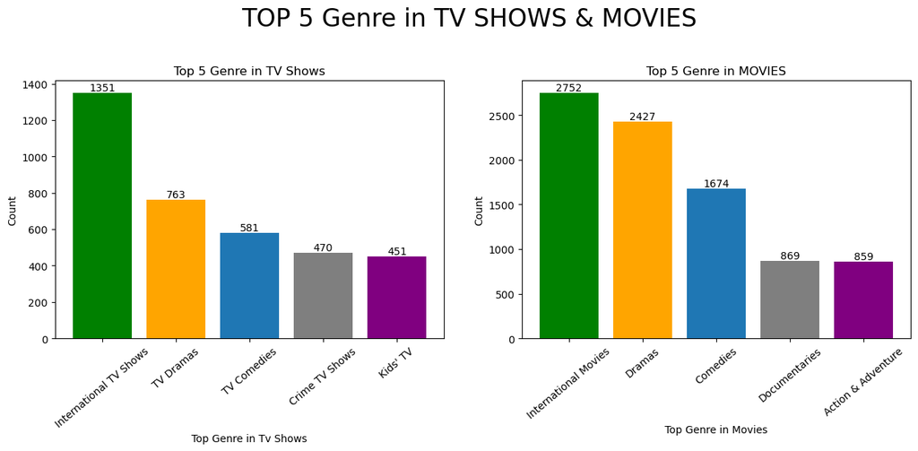

```python
#TOP 5 Genre in TV SHOWS & MOVIES
#Graphical RepresentatioTn using bar plot
fig = plt.figure (figsize= (15,10))
plt.subplot (2,2,1)
df_genre = df_tv.groupby("listed_in").agg({"title":"nunique"}).sort_values(by = ["title"], ascending=False).reset_index().head(5)
x = df_genre["listed_in"]
y = df_genre["title"]
height = plt.bar(x,y, color = ("g","orange","tab:blue", "tab:gray", "purple"))
for bar in height:
    yval = bar.get_height()
    plt.text(bar.get_x() + bar.get_width()/2, yval, str(yval), ha = "center", va = "bottom")
plt.xticks(rotation = 40)
plt.title("Top 5 Genre in TV Shows")
plt.xlabel("Top Genre in Tv Shows")
plt.ylabel("Count")

plt.subplot (2,2,2)
df_genre_m = df_movies.groupby("listed_in").agg({"title":"nunique"}).sort_values(by = ["title"], ascending=False).reset_index().head(5)
x = df_genre_m["listed_in"]
y = df_genre_m["title"]
height = plt.bar(x,y, color = ("g","orange","tab:blue", "tab:gray", "purple"))
for bar in height:
    yval = bar.get_height()
    plt.text(bar.get_x() + bar.get_width()/2, yval, str(yval), ha = "center", va = "bottom")
plt.xticks(rotation = 40)
plt.title("Top 5 Genre in MOVIES")
plt.xlabel("Top Genre in Movies")
plt.ylabel("Count")
plt.suptitle("TOP 5 Genre in TV SHOWS & MOVIES", fontsize = 24)
plt.show()
```

# TOP 5 Directors in TV SHOWS & MOVIES

```python
# to find which director had more movies
df_more_movies = df_movies.groupby("director").agg({"title":"nunique"}).sort_values(by = ["title"], ascending=False).reset_index()
df_more_movies = df_more_movies[df_more_movies["director"]!= "Unknown Directors"]
df_more_movies.head(5)
```

|  | director | title |
| --- | --- | --- |
| 1 | Rajiv Chilaka | 22 |
| 2 | Jan Suter | 21 |
| 3 | Raúl Campos | 19 |
| 4 | Suhas Kadav | 16 |
| 5 | Marcus Raboy | 15 |

```python
# to find which director had more TV Shows
df_more_tv = df_tv.groupby("director").agg({"title":"nunique"}).sort_values(by = ["title"], ascending=False).reset_index()
df_more_tv = df_more_tv[df_more_tv["director"]!= "Unknown Directors"]
df_more_tv.head(5)
```

|  | director | title |
| --- | --- | --- |
| 1 | Ken Burns | 3 |
| 2 | Alastair Fothergill | 3 |
| 3 | Stan Lathan | 2 |
| 4 | Joe Berlinger | 2 |
| 5 | Hsu Fu-chun | 2 |

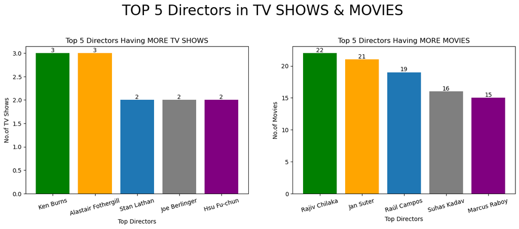

```python
#TOP 5 Directors in TV SHOWS & MOVIES
#Graphical RepresentatioTn using bar plot
fig = plt.figure (figsize= (15,10))
plt.subplot (2,2,1)
df_more_tv_top5 = df_more_tv.head(5)
x= df_more_tv_top5["director"]
y = df_more_tv_top5["title"]
height = plt.bar(x, y, color = ("g","orange","tab:blue", "tab:gray", "purple"))
for bar in height:
    yval = bar.get_height()
    plt.text(bar.get_x() + bar.get_width()/2, yval, str(yval), ha = "center", va = "bottom")
plt.title("Top 5 Directors Having MORE TV SHOWS")
plt.xlabel("Top Directors")
plt.ylabel("No.of TV Shows")
plt.xticks(rotation = 15)

plt.subplot (2,2,2)
df_more_movies_top5 = df_more_movies.head(5)
x= df_more_movies_top5["director"]
y = df_more_movies_top5["title"]
height = plt.bar(x, y, color = ("g","orange","tab:blue", "tab:gray", "purple"))
for bar in height:
    yval = bar.get_height()
    plt.text(bar.get_x() + bar.get_width()/2, yval, str(yval), ha = "center", va = "bottom")
plt.title("Top 5 Directors Having MORE MOVIES")
plt.xlabel("Top Directors")
plt.ylabel("No.of Movies")
plt.xticks(rotation = 15)
plt.suptitle("TOP 5 Directors in TV SHOWS & MOVIES", fontsize = 24)
plt.show()
```

# TOP 5 Cast in TV SHOWS & MOVIES

```python
# to find Top 5 Cast in Movies
df_c_movies = df_movies.groupby("cast").agg({"title":"nunique"}).sort_values(by = ["title"], ascending=False).reset_index()
df_c_movies = df_c_movies[df_c_movies["cast"]!= "Unknown Actor"]
df_c_movies.head(5)
```

|  | cast | title |
| --- | --- | --- |
| 1 | Anupam Kher | 42 |
| 2 | Shah Rukh Khan | 35 |
| 3 | Naseeruddin Shah | 32 |
| 4 | Om Puri | 30 |
| 5 | Akshay Kumar | 30 |

```python
# to find Top 5 Cast in TV Shows
df_c_tv = df_tv.groupby("cast").agg({"title":"nunique"}).sort_values(by = ["title"], ascending=False).reset_index()
df_c_tv = df_c_tv[df_c_tv["cast"]!= "Unknown Actor"]
df_c_tv.head(5)
```

|  | cast | title |
| --- | --- | --- |
| 1 | Takahiro Sakurai | 25 |
| 2 | Yuki Kaji | 19 |
| 3 | Junichi Suwabe | 17 |
| 4 | Daisuke Ono | 17 |
| 5 | Ai Kayano | 17 |

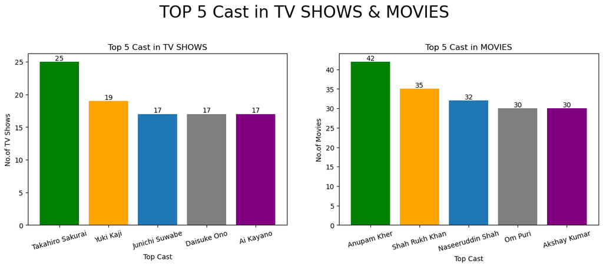

```python
#TOP 5 Cast in TV SHOWS & MOVIES
#Graphical RepresentatioTn using bar plot
fig = plt.figure (figsize= (15,10))
plt.subplot (2,2,1)
df_c_tv_top5 = df_c_tv.head(5)
x= df_c_tv_top5["cast"]
y = df_c_tv_top5["title"]
height = plt.bar(x, y, color = ("g","orange","tab:blue", "tab:gray", "purple"))
for bar in height:
    yval = bar.get_height()
    plt.text(bar.get_x() + bar.get_width()/2, yval, str(yval), ha = "center", va = "bottom")
plt.title("Top 5 Cast in TV SHOWS")
plt.xlabel("Top Cast")
plt.ylabel("No.of TV Shows")
plt.xticks(rotation = 15)

plt.subplot (2,2,2)
df_c_movies_top5 = df_c_movies.head(5)
x= df_c_movies_top5["cast"]
y = df_c_movies_top5["title"]
height = plt.bar(x, y, color = ("g","orange","tab:blue", "tab:gray", "purple"))
for bar in height:
    yval = bar.get_height()
    plt.text(bar.get_x() + bar.get_width()/2, yval, str(yval), ha = "center", va = "bottom")
plt.title("Top 5 Cast in MOVIES")
plt.xlabel("Top Cast")
plt.ylabel("No.of Movies")
plt.xticks(rotation = 15)
plt.suptitle("TOP 5 Cast in TV SHOWS & MOVIES", fontsize = 24)
plt.show()
```

# Highest No.Of Shows added in Netflix in the Year 2020

```python
# In which year highest no.of TV Schows were Added?
df_tv_year = df_tv.groupby("year").agg({"title":"nunique"}).reset_index()
df_tv_year.head()
```

|  | year | title |
| --- | --- | --- |
| 0 | 2008 | 1 |
| 1 | 2013 | 5 |
| 2 | 2014 | 5 |
| 3 | 2015 | 26 |
| 4 | 2016 | 179 |

# Highest No.Of Movies was added in Netflix in the Year 2019

```python
# In which year highest no.of Movies were Added?
df_mov_year = df_movies.groupby("year").agg({"title":"nunique"}).reset_index()
df_mov_year.head()
```

|  | year | title |
| --- | --- | --- |
| 0 | 2008 | 1 |
| 1 | 2009 | 2 |
| 2 | 2010 | 1 |
| 3 | 2011 | 13 |
| 4 | 2012 | 3 |

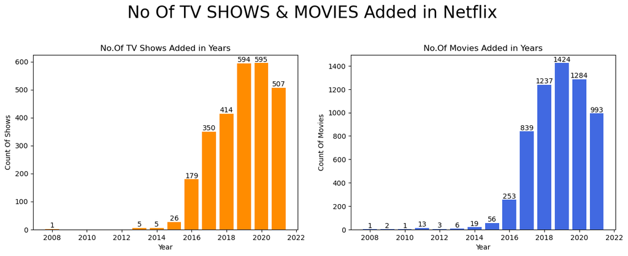

```python
#Graphical Representation using bar plot
fig = plt.figure (figsize= (15,10))
plt.subplot (2,2,1)
x = df_tv_year["year"]
y = df_tv_year["title"]
height = plt.bar(x,y, color ="darkorange")
for bar in height:
    yval = bar.get_height()
    plt.text(bar.get_x() + bar.get_width()/2, yval, str(yval), ha = "center", va = "bottom")
plt.title("No.Of TV Shows Added in Years")
plt.xlabel("Year")
plt.ylabel("Count Of Shows")

plt.subplot (2,2,2)
x = df_mov_year["year"]
y = df_mov_year["title"]
height = plt.bar(x,y, color ="royalblue")
for bar in height:
    yval = bar.get_height()
    plt.text(bar.get_x() + bar.get_width()/2, yval, str(yval), ha = "center", va = "bottom")
plt.title("No.Of Movies Added in Years")
plt.xlabel("Year")
plt.ylabel("Count Of Movies")
plt.suptitle("No Of TV SHOWS & MOVIES Added in Netflix ", fontsize = 24)
plt.show()
```

# Highest No.Of Movies released in the Year 2017 & 2018

```python
# In which year highest no.of Movies were released?
df_mov_y = df_movies.groupby("release_year").agg({"title":"nunique"}).reset_index()
df_mov_y.head()
```

|  | release_year | title |
| --- | --- | --- |
| 0 | 1942 | 2 |
| 1 | 1943 | 3 |
| 2 | 1944 | 3 |
| 3 | 1945 | 3 |
| 4 | 1946 | 1 |

# Highest No.Of TV Shows released in the Year 2020

```python
# In which year highest no.of TV Schows were Released?
df_tv_y = df_tv.groupby("release_year").agg({"title":"nunique"}).reset_index()
df_tv_y.tail()
```

|  | release_year | title |
| --- | --- | --- |
| 41 | 2017 | 265 |
| 42 | 2018 | 380 |
| 43 | 2019 | 397 |
| 44 | 2020 | 436 |
| 45 | 2021 | 315 |

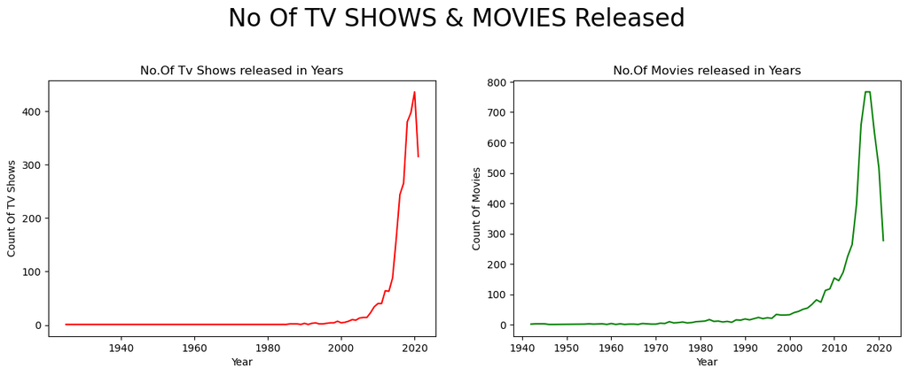

```python
#Graphical Representation using Line plot
fig = plt.figure (figsize= (15,10))
plt.subplot (2,2,1)
x = df_tv_y["release_year"]
y = df_tv_y["title"]
plt.plot(x,y, color ="r")
plt.title("No.Of Tv Shows released in Years")
plt.xlabel("Year")
plt.ylabel("Count Of TV Shows")

plt.subplot (2,2,2)
x = df_mov_y["release_year"]
y = df_mov_y["title"]
plt.plot(x,y, color ="g")
plt.title("No.Of Movies released in Years")
plt.xlabel("Year")
plt.ylabel("Count Of Movies")
plt.suptitle("No Of TV SHOWS & MOVIES Released ", fontsize = 24)
plt.show()
```

# Top 5 Ratings in TV SHOWS & MOVIES

```python
# the ratings of the most movies and tvshows
movies = df_movies.groupby(["rating"]).agg({"title":"nunique"}).reset_index().sort_values(by=["title"],ascending=False).head(5)
tvshows = df_tv.groupby(["rating"]).agg({"title":"nunique"}).reset_index().sort_values(by=["title"],ascending=False).head(5)
print(movies)
print()
print(tvshows)
```

```
  rating  title
8  TV-MA   2062
6  TV-14   1427
5      R    797
9  TV-PG    540
4  PG-13    490

  rating  title
4  TV-MA   1145
2  TV-14    733
5  TV-PG    323
7  TV-Y7    195
6   TV-Y    176
```

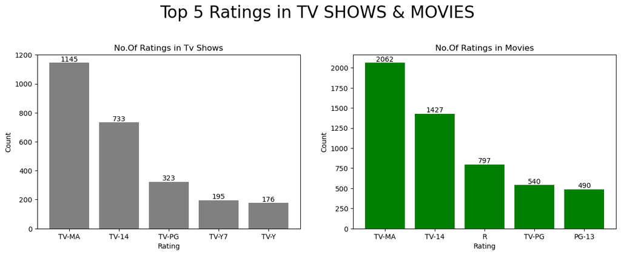

```python
#Graphical Representation using Bar plot
fig = plt.figure (figsize= (15,10))
plt.subplot (2,2,1)
x = tvshows["rating"]
y = tvshows["title"]
height = plt.bar(x,y, color ="gray")
for bar in height:
    yval = bar.get_height()
    plt.text(bar.get_x() + bar.get_width()/2, yval, str(yval), ha = "center", va = "bottom")
plt.title("No.Of Ratings in Tv Shows")
plt.xlabel("Rating")
plt.ylabel("Count")

plt.subplot (2,2,2)
x = movies["rating"]
y = movies["title"]
height = plt.bar(x,y, color ="g")
for bar in height:
    yval = bar.get_height()
    plt.text(bar.get_x() + bar.get_width()/2, yval, str(yval), ha = "center", va = "bottom")
plt.title("No.Of Ratings in Movies")
plt.xlabel("Rating")
plt.ylabel("Count")
plt.suptitle("Top 5 Ratings in TV SHOWS & MOVIES", fontsize = 24)
plt.show()
```

# TOP 5 Actors in Indian TV SHOWS & MOVIES

```python
indian_movies = df_movies[df_movies["country"]== "India"]
indian_movies_g = indian_movies.groupby("cast").agg({"title":"nunique"}).sort_values(by = ["title"], ascending=False).reset_index()
indian_movies_g= indian_movies_g[indian_movies_g["cast"]!= "Unknown Actor"]
indian_movies_g.head()
```

|  | cast | title |
| --- | --- | --- |
| 0 | Anupam Kher | 40 |
| 1 | Shah Rukh Khan | 35 |
| 2 | Naseeruddin Shah | 32 |
| 3 | Akshay Kumar | 29 |
| 4 | Om Puri | 29 |

```python
indian_tv = df_tv[df_tv["country"]== "India"]
indian_tv_g = indian_tv.groupby("cast").agg({"title":"nunique"}).sort_values(by = ["title"], ascending=False).reset_index()
indian_tv_g= indian_tv_g[indian_tv_g["cast"]!= "Unknown Actor"]
indian_tv_g.head(5)
```

|  | cast | title |
| --- | --- | --- |
| 1 | Rajesh Kava | 3 |
| 2 | Nishka Raheja | 3 |
| 3 | Prakash Raj | 2 |
| 4 | Sabina Malik | 2 |
| 5 | Anjali | 2 |

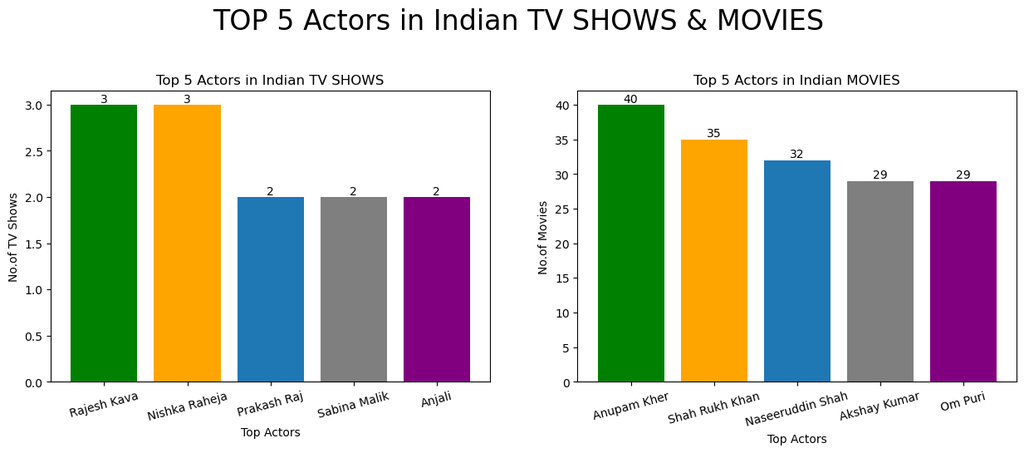

```python
#TOP 5 Cast in Indian TV SHOWS & MOVIES
#Graphical RepresentatioTn using bar plot
fig = plt.figure (figsize= (15,10))
plt.subplot (2,2,1)
indian_tv_t_c = indian_tv_g.head(5)
x= indian_tv_t_c["cast"]
y = indian_tv_t_c["title"]
height = plt.bar(x, y, color = ("g","orange","tab:blue", "tab:gray", "purple"))
for bar in height:
    yval = bar.get_height()
    plt.text(bar.get_x() + bar.get_width()/2, yval, str(yval), ha = "center", va = "bottom")
plt.title("Top 5 Actors in Indian TV SHOWS")
plt.xlabel("Top Actors")
plt.ylabel("No.of TV Shows")
plt.xticks(rotation = 15)

plt.subplot (2,2,2)
indian_mov_t_c = indian_movies_g.head(5)
x= indian_mov_t_c["cast"]
y = indian_mov_t_c["title"]
height = plt.bar(x, y, color = ("g","orange","tab:blue", "tab:gray", "purple"))
for bar in height:
    yval = bar.get_height()
    plt.text(bar.get_x() + bar.get_width()/2, yval, str(yval), ha = "center", va = "bottom")
plt.title("Top 5 Actors in Indian MOVIES")
plt.xlabel("Top Actors")
plt.ylabel("No.of Movies")
plt.xticks(rotation = 15)
plt.suptitle("TOP 5 Actors in Indian TV SHOWS & MOVIES", fontsize = 24)
plt.show()
```

# TOP 5 Directors in Indian TV SHOWS & MOVIES

```python
# to find which indian director had more Movies
indian_movies = df_movies[df_movies["country"]== "India"]
indian_movies_g_d = indian_movies.groupby("director").agg({"title":"nunique"}).sort_values(by = ["title"], ascending=False).reset_index()
indian_movies_g_d= indian_movies_g_d[indian_movies_g_d["director"]!= "Unknown Directors"]
indian_movies_g_d.head()
```

|  | director | title |
| --- | --- | --- |
| 0 | Rajiv Chilaka | 22 |
| 1 | Suhas Kadav | 16 |
| 3 | David Dhawan | 9 |
| 4 | Umesh Mehra | 8 |
| 5 | Anurag Kashyap | 8 |

```python
# to find which indian director had more Tv Shows
indian_tv = df_tv[df_tv["country"]== "India"]
indian_tv_g_d = indian_tv.groupby("director").agg({"title":"nunique"}).sort_values(by = ["title"], ascending=False).reset_index()
indian_tv_g_d= indian_tv_g_d[indian_tv_g_d["director"]!= "Unknown Directors"]
indian_tv_g_d.head(5)
```

|  | director | title |
| --- | --- | --- |
| 1 | Gautham Vasudev Menon | 2 |
| 2 | Abhishek Chaubey | 1 |
| 3 | Sudha Kongara | 1 |
| 4 | Rathindran R Prasad | 1 |
| 5 | Sankalp Reddy | 1 |

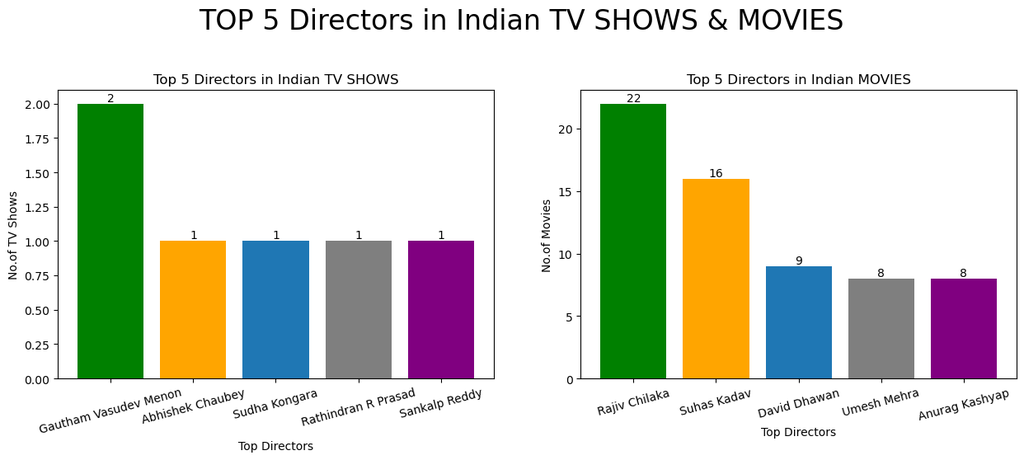

```python
#TOP 5 Directors in Indian TV SHOWS & MOVIES
#Graphical RepresentatioTn using bar plot
fig = plt.figure (figsize= (15,10))
plt.subplot (2,2,1)
indian_tv_t_d = indian_tv_g_d.head(5)
x= indian_tv_t_d["director"]
y = indian_tv_t_d["title"]
height = plt.bar(x, y, color = ("g","orange","tab:blue", "tab:gray", "purple"))
for bar in height:
    yval = bar.get_height()
    plt.text(bar.get_x() + bar.get_width()/2, yval, str(yval), ha = "center", va = "bottom")
plt.title("Top 5 Directors in Indian TV SHOWS")
plt.xlabel("Top Directors")
plt.ylabel("No.of TV Shows")
plt.xticks(rotation = 15)

plt.subplot (2,2,2)
indian_mov_t_d = indian_movies_g_d.head(5)
x= indian_mov_t_d["director"]
y = indian_mov_t_d["title"]
height = plt.bar(x, y, color = ("g","orange","tab:blue", "tab:gray", "purple"))
for bar in height:
    yval = bar.get_height()
    plt.text(bar.get_x() + bar.get_width()/2, yval, str(yval), ha = "center", va = "bottom")
plt.title("Top 5 Directors in Indian MOVIES")
plt.xlabel("Top Directors")
plt.ylabel("No.of Movies")
plt.xticks(rotation = 15)
plt.suptitle("TOP 5 Directors in Indian TV SHOWS & MOVIES", fontsize = 24)
plt.show()
```

# TOP 10 Countries Releasing TV SHOWS & MOVIES

We can understand United States, United Kingdom, Japan, South Korea & Canada are producing More TV Shows

If we look into Movies We can see United States, India, United Kingdom, Canada, France are Producing More Movies.

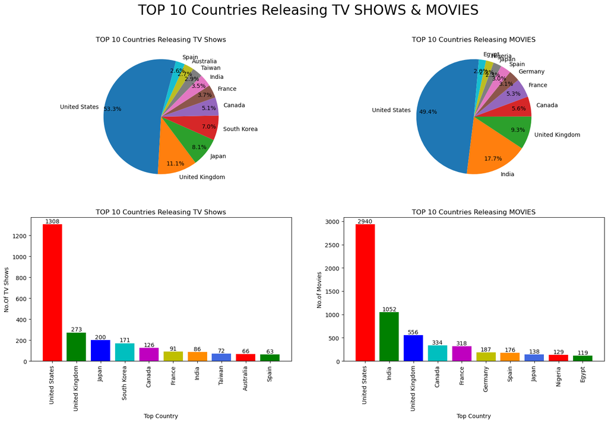

```python
# Percentage of TV SHOWS & MOVIES Releasing by Countries
#Graphical RepresentatioTn using Pie Chart
fig = plt.figure (figsize= (18,10))
plt.subplot (2,2,1)
df_country_t = df_tv.groupby("country").agg({"title":"nunique"}).sort_values(by = ["title"], ascending=False).reset_index().head(10)
x = df_country_t["country"]
y = df_country_t["title"]
plt.pie(y, labels = x, autopct = "%1.1f%%",startangle=75, pctdistance = 0.85)
plt.title("TOP 10 Countries Releasing TV Shows")

plt.subplot (2,2,2)
df_country_m = df_movies.groupby("country").agg({"title":"nunique"}).sort_values(by = ["title"], ascending=False).reset_index()
df_country_m= df_country_m[df_country_m["country"]!= "Unknown Country"]
df_country_m = df_country_m.head(10)
x = df_country_m["country"]
y = df_country_m["title"]
plt.pie(y,labels = x, autopct = "%1.1f%%",startangle=85, pctdistance = 0.8)
plt.title("TOP 10 Countries Releasing MOVIES")
plt.suptitle("TOP 10 Countries Releasing TV SHOWS & MOVIES", fontsize = 24)

# Top 10 Countries Releasing TV SHOWS & MOVIES
#Graphical RepresentatioTn using Bar plot
colors = ["r","g","b","c","m","y","darkorange","royalblue"]
plt.subplot (2,2,3)
df_country_t = df_tv.groupby("country").agg({"title":"nunique"}).sort_values(by = ["title"], ascending=False).reset_index().head(10)
x = df_country_t["country"]
y = df_country_t["title"]
height = plt.bar(x,y, color = colors)
for bar in height:
    yval = bar.get_height()
    plt.text(bar.get_x() + bar.get_width()/2, yval, str(yval), ha = "center", va = "bottom")
plt.xlabel("Top Country")
plt.ylabel("No.Of TV Shows")
plt.xticks(rotation = 90)
plt.title("TOP 10 Countries Releasing TV Shows")

plt.subplot (2,2,4)
df_country_m = df_movies.groupby("country").agg({"title":"nunique"}).sort_values(by = ["title"], ascending=False).reset_index()
df_country_m= df_country_m[df_country_m["country"]!= "Unknown Country"]
df_country_m = df_country_m.head(10)
x = df_country_m["country"]
y = df_country_m["title"]
height = plt.bar(x,y, color = colors)
for bar in height:
    yval = bar.get_height()
    plt.text(bar.get_x() + bar.get_width()/2, yval, str(yval), ha = "center", va = "bottom")
plt.title("TOP 10 Countries Releasing MOVIES")
plt.xlabel("Top Country")
plt.ylabel("No.of Movies")
plt.xticks(rotation = 90)
plt.suptitle("TOP 10 Countries Releasing TV SHOWS & MOVIES", fontsize = 24)
plt.show()
```

# How many Movies/ TV Shows Released in Which Month of the Year

```python
df_mov1 = df_movies.groupby(["month","type"]).agg({"title":"nunique"}).reset_index()
df_mov1.head()
```

|  | month | type | title |
| --- | --- | --- | --- |
| 0 | 1 | Movie | 546 |
| 1 | 2 | Movie | 382 |
| 2 | 3 | Movie | 529 |
| 3 | 4 | Movie | 550 |
| 4 | 5 | Movie | 439 |

```python
df_tv1 = df_tv.groupby(["month","type"]).agg({"title":"nunique"}).reset_index()
df_tv1.head()
```

|  | month | type | title |
| --- | --- | --- | --- |
| 0 | 1 | TV Show | 192 |
| 1 | 2 | TV Show | 181 |
| 2 | 3 | TV Show | 213 |
| 3 | 4 | TV Show | 215 |
| 4 | 5 | TV Show | 193 |

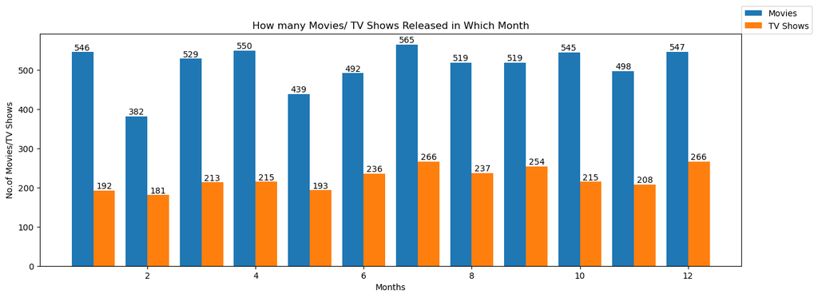

```python
fig = plt.figure(figsize = (15, 5))
height = plt.bar(df_mov1["month"]  -0.2 , df_mov1["title"] , - 0.4, label = "Movies" )
for bar in height:
    yval = bar.get_height()
    plt.text(bar.get_x() + bar.get_width()/2, yval, str(yval), ha = "center", va = "bottom")
height = plt.bar(df_tv1["month"]  + 0.2 ,df_tv1["title"] , +0.4, label = "TV Shows")
for bar in height:
    yval = bar.get_height()
    plt.text(bar.get_x() + bar.get_width()/2, yval, str(yval), ha = "center", va = "bottom")
plt.legend(loc = (1,1))
plt.title("How many Movies/ TV Shows Released in Which Month")
plt.xlabel("Months")
plt.ylabel("No.of Movies/TV Shows")
plt.show()
```

# Heat Map & Pair plots

```
1) we will create more numerical fields to get a Heat map and pairplot here
2) although there are no meaningful numerical features in this dataset, but we can attempt to see if we can find something interesting in the data that we have.
```

```python
df_dur = df_movies.groupby(["duration","release_year","year","month","day"]).agg({"title":"nunique"}).sort_values(by = ["title"], ascending=False).reset_index()
df_dur.head(5)
```

|  | duration | release_year | year | month | day | title |
| --- | --- | --- | --- | --- | --- | --- |
| 0 | 53 | 2017 | 2019 | 7 | 1 | 6 |
| 1 | 54 | 2017 | 2019 | 7 | 1 | 6 |
| 2 | 64 | 2013 | 2021 | 7 | 22 | 5 |
| 3 | 122 | 2021 | 2021 | 8 | 23 | 4 |
| 4 | 97 | 2010 | 2020 | 1 | 1 | 3 |

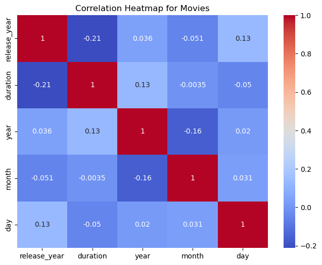

```python
# Correlation Heatmap for Movies
correlation_matrix = df_dur[["release_year", "duration","year","month","day"]].corr()
plt.figure(figsize=(8, 6))
sns.heatmap(correlation_matrix, annot=True, cmap="coolwarm")
plt.title('Correlation Heatmap for Movies')
plt.show()
```

```python
df_dur_tv = df_tv.groupby(["duration","release_year","year","month","day"]).agg({"title":"nunique"}).sort_values(by = ["title"], ascending=False).reset_index()
df_dur_tv.head(5)
```

|  | duration | release_year | year | month | day | title |
| --- | --- | --- | --- | --- | --- | --- |
| 0 | 1 | 2016 | 2017 | 8 | 1 | 8 |
| 1 | 1 | 2012 | 2016 | 12 | 15 | 7 |
| 2 | 1 | 2018 | 2018 | 10 | 1 | 6 |
| 3 | 1 | 2014 | 2017 | 7 | 1 | 6 |
| 4 | 1 | 2019 | 2019 | 8 | 16 | 6 |

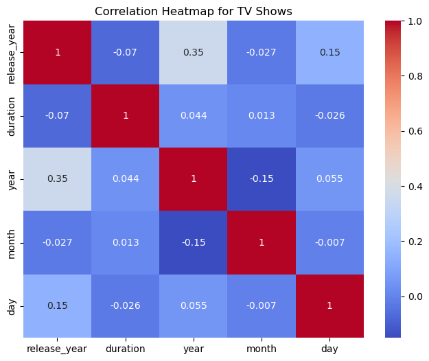

```python
# Correlation Heatmap for TV Shows
correlation_matrix = df_dur_tv[["release_year", "duration","year","month","day"]].corr()
plt.figure(figsize=(8, 6))
sns.heatmap(correlation_matrix, annot=True, cmap="coolwarm")
plt.title('Correlation Heatmap for TV Shows')
plt.show()
```

# Pair Plot

```python
df_dur_pair = df_final.groupby(["duration","release_year","year","month","day","type"]).agg({"title":"nunique"}).sort_values(by = ["title"], ascending=False).reset_index()
df_dur_pair.head(5)
```

|  | duration | release_year | year | month | day | type | title |
| --- | --- | --- | --- | --- | --- | --- | --- |
| 0 | 1 | 2016 | 2017 | 8 | 1 | TV Show | 8 |
| 1 | 1 | 2012 | 2016 | 12 | 15 | TV Show | 7 |
| 2 | 54 | 2017 | 2019 | 7 | 1 | Movie | 6 |
| 3 | 53 | 2017 | 2019 | 7 | 1 | Movie | 6 |
| 4 | 1 | 2019 | 2019 | 8 | 16 | TV Show | 6 |

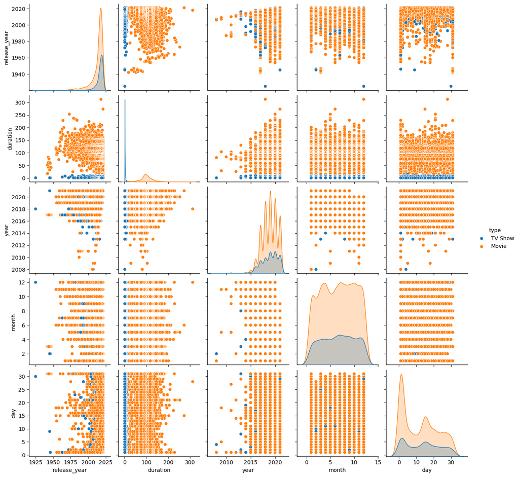

```python
# Pair plot for the Numerical columns available in the data set
sns.pairplot(df_dur_pair[["release_year", "duration","year","month","day","type"]], hue="type")
plt.show()
```

# How has the number of movies/Tv shows released per year changed over the last 20–30 years?

• Growth in Number of Movies and TV shows skyrocketed since 2014

• The pace of Movie releases was somewhat slow until 1996, but since 1996 ther’s been notable increase in the realese of movies and Tv shows started out with good pace since 2005

• It is interesting to note that, TV Shows ended up in higher side on comparison with movies

```python
titles_per_year_type = df_final.groupby(['release_year', 'type']).agg({"title": "nunique"}).reset_index()[57:]
titles_per_year_type.head()
```

|  | release_year | type | title |
| --- | --- | --- | --- |
| 57 | 1991 | Movie | 16 |
| 58 | 1991 | TV Show | 1 |
| 59 | 1992 | Movie | 20 |
| 60 | 1992 | TV Show | 3 |
| 61 | 1993 | Movie | 24 |

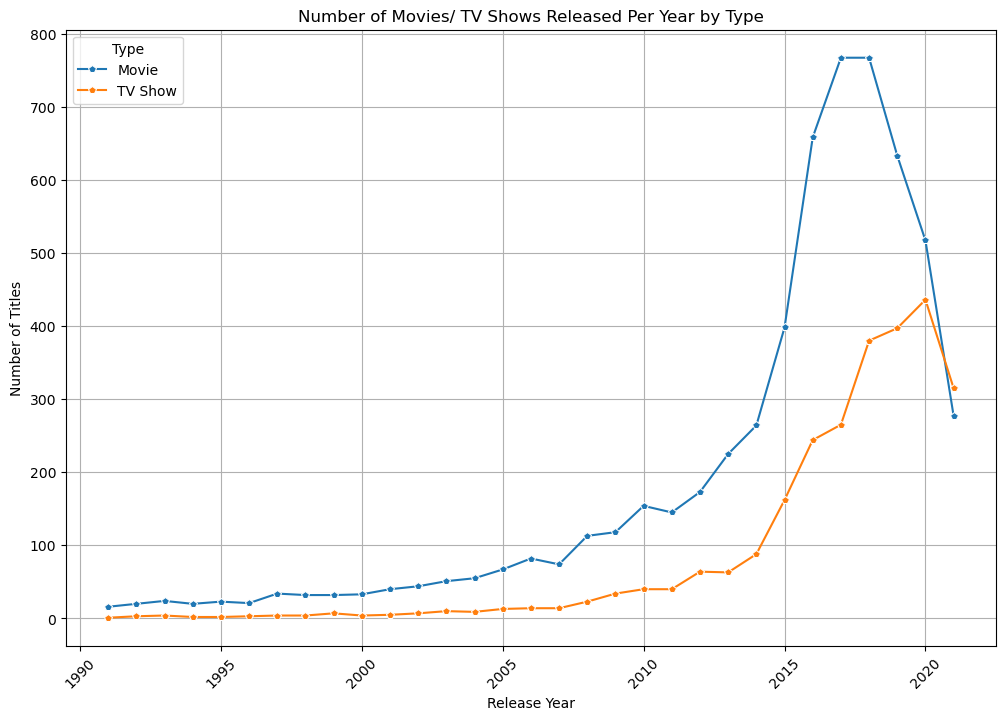

```python
# Plot the number of titles released per year with hue as type
plt.figure(figsize=(12, 8))
sns.lineplot(x='release_year', y='title', hue='type', data=titles_per_year_type, marker='p')
plt.xlabel('Release Year')
plt.ylabel('Number of Titles')
plt.title('Number of Movies/ TV Shows Released Per Year by Type')
plt.xticks(rotation=45)
plt.grid(True)
plt.legend(title='Type')
plt.show()
```

# Finding Outliers in No.of Seasons in TV Shows & the Duration of Movies

```python
# Finding Outliers in No.of Seasons in TV Shows
df_dur = df_tv.groupby(["duration","type"]).agg({"title":"nunique"}).sort_values(by = ["title"], ascending=False).reset_index()
df_dur.head(5)
```

|  | duration | type | title |
| --- | --- | --- | --- |
| 0 | 1 | TV Show | 1793 |
| 1 | 2 | TV Show | 425 |
| 2 | 3 | TV Show | 199 |
| 3 | 4 | TV Show | 95 |
| 4 | 5 | TV Show | 65 |

```python
# Finding Outliers in movie duration in Movies
df_dur_m = df_movies.groupby(["duration","type"]).agg({"title":"nunique"}).sort_values(by = ["title"], ascending=False).reset_index()
df_dur_m.head(5)
```

|  | duration | type | title |
| --- | --- | --- | --- |
| 0 | 90 | Movie | 152 |
| 1 | 97 | Movie | 146 |
| 2 | 93 | Movie | 146 |
| 3 | 94 | Movie | 146 |
| 4 | 91 | Movie | 144 |

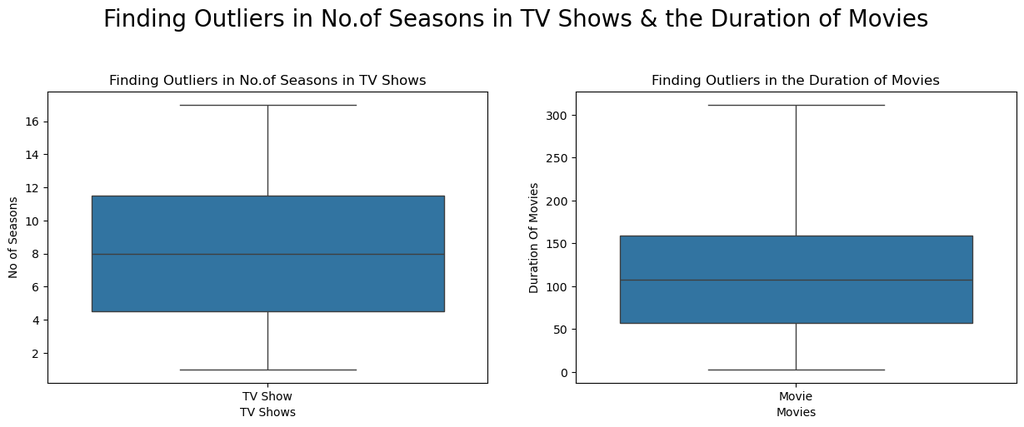

```python
#Finding Outliers in No.of Seasons in TV Shows & the Duration of Movies
#Graphical RepresentatioTn using box plot
fig = plt.figure (figsize= (15,10))
plt.subplot (2,2,1)
sns.boxplot (x = "type", y = "duration", data = df_dur)
plt.title("Finding Outliers in No.of Seasons in TV Shows")
plt.xlabel("TV Shows")
plt.ylabel("No of Seasons")

plt.subplot (2,2,2)
sns.boxplot (x = "type", y = "duration", data = df_dur_m)
plt.title("Finding Outliers in the Duration of Movies")
plt.xlabel("Movies")
plt.ylabel("Duration Of Movies")
plt.suptitle("Finding Outliers in No.of Seasons in TV Shows & the Duration of Movies", fontsize = 20)
plt.show()
```

# What is the best time to launch a TV show?

#### Best Month to release a TV Show is July and December

#### Best Month to release a Movie is July

```python
df_mov_month = df_movies.groupby("month").agg({"title":"nunique"}).reset_index()
df_mov_month.head()
```

|  | month | title |
| --- | --- | --- |
| 0 | 1 | 546 |
| 1 | 2 | 382 |
| 2 | 3 | 529 |
| 3 | 4 | 550 |
| 4 | 5 | 439 |

```python
df_tv_month = df_tv.groupby("month").agg({"title":"nunique"}).reset_index()
df_tv_month.head()
```

|  | month | title |
| --- | --- | --- |
| 0 | 1 | 192 |
| 1 | 2 | 181 |
| 2 | 3 | 213 |
| 3 | 4 | 215 |
| 4 | 5 | 193 |

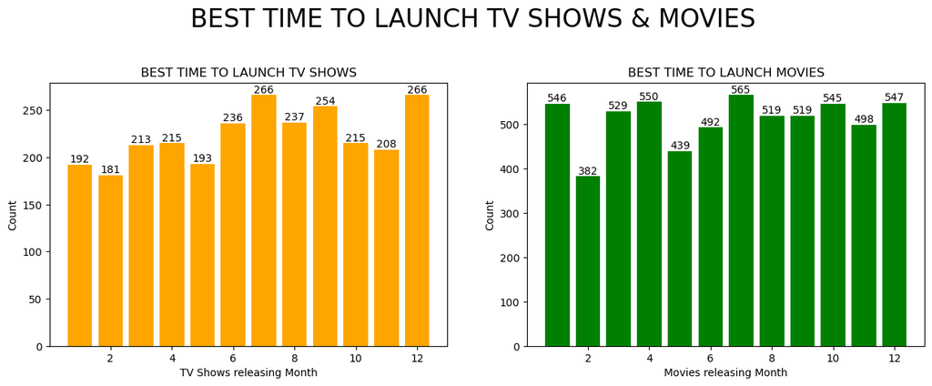

```python
#Graphical Representation using Bar plot
fig = plt.figure (figsize= (15,10))
plt.subplot (2,2,1)
x = df_tv_month["month"]
y = df_tv_month["title"]
height = plt.bar(x,y, color ="orange")
for bar in height:
    yval = bar.get_height()
    plt.text(bar.get_x() + bar.get_width()/2, yval, str(yval), ha = "center", va = "bottom")
plt.title("BEST TIME TO LAUNCH TV SHOWS")
plt.xlabel("TV Shows releasing Month")
plt.ylabel("Count")

plt.subplot (2,2,2)
x = df_mov_month["month"]
y = df_mov_month["title"]
height = plt.bar(x,y, color ="g")
for bar in height:
    yval = bar.get_height()
    plt.text(bar.get_x() + bar.get_width()/2, yval, str(yval), ha = "center", va = "bottom")
plt.title("BEST TIME TO LAUNCH MOVIES")
plt.xlabel("Movies releasing Month")
plt.ylabel("Count")
plt.suptitle("BEST TIME TO LAUNCH TV SHOWS & MOVIES", fontsize = 24)
plt.show()
```

# Understanding what content is available in different countries

# Top 5 Countries with Number of Titles per Top 5 Genre in Movies

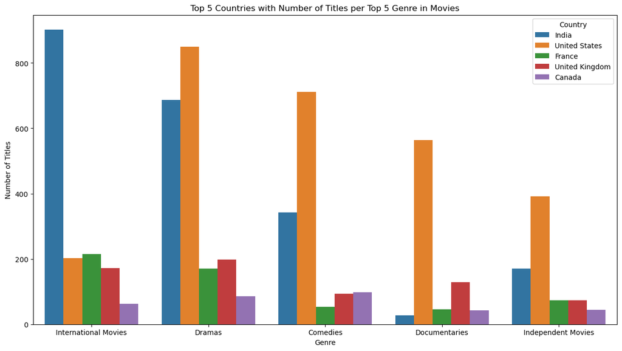

```python
# Group by country and count the number of unique titles
country_titles_m = df_movies.groupby('country').agg({"title": "nunique"}).reset_index()
top_5_countries = country_titles_m.sort_values(by='title', ascending=False).head(5)

# Filter the dataset to include only the top 5 countries
top_5_country_filter = df_movies[df_movies['country'].isin(top_5_countries['country'])]
country_genre_titles = top_5_country_filter.groupby(['country', 'listed_in']).agg({"title": "nunique"}).reset_index()
genre_counts = top_5_country_filter.groupby('listed_in')['title'].nunique().reset_index()

top_genres = genre_counts.sort_values(by='title', ascending=False).head(5)['listed_in'].tolist()

country_genre_titles_top5 = country_genre_titles[country_genre_titles['listed_in'].isin(top_genres)].sort_values(by='title', ascending=False)

plt.figure(figsize=(15, 8))
sns.barplot(y='title', x='listed_in', hue='country', data=country_genre_titles_top5)
plt.xlabel('Genre')
plt.ylabel('Number of Titles')
plt.title('Top 5 Countries with Number of Titles per Top 5 Genre in Movies')
plt.legend(title='Country')
plt.show()
```

# Top 5 Countries with Number of Titles per Top 5 Genre in TV Shows

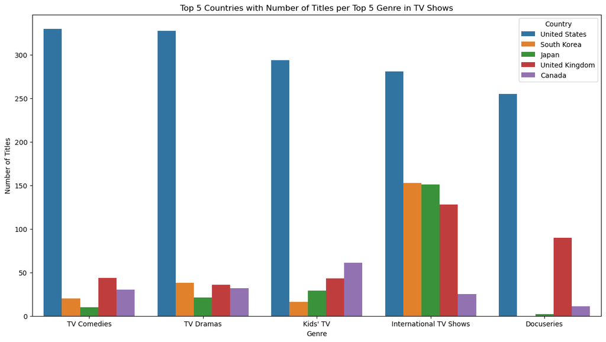

```python
# Group by country and count the number of unique titles
country_titles_t = df_tv.groupby('country').agg({"title": "nunique"}).reset_index()
top_5_countries_t = country_titles_t.sort_values(by='title', ascending=False).head(5)

# Filter the dataset to include only the top 5 countries
top_5_country_filter_t = df_tv[df_tv['country'].isin(top_5_countries_t['country'])]
country_genre_titles_t = top_5_country_filter_t.groupby(['country', 'listed_in']).agg({"title": "nunique"}).reset_index()
genre_counts_t = top_5_country_filter_t.groupby('listed_in')['title'].nunique().reset_index()

top_genres_t = genre_counts_t.sort_values(by='title', ascending=False).head(5)['listed_in'].tolist()

country_genre_titles_top5_t = country_genre_titles_t[country_genre_titles_t['listed_in'].isin(top_genres_t)].sort_values(by='title', ascending=False)

plt.figure(figsize=(15, 8))
sns.barplot(y='title', x='listed_in', hue='country', data=country_genre_titles_top5_t)
plt.xlabel('Genre')
plt.ylabel('Number of Titles')
plt.title('Top 5 Countries with Number of Titles per Top 5 Genre in TV Shows')
plt.legend(title='Country')
plt.show()
```

# Distribution of TV SHOWS & MOVIES by Date Added in Netflix

```python
df_t_d = df_tv.groupby("date_added").agg({"title":"nunique"}).reset_index()
df_t_d.head(5)
```

|  | date_added | title |
| --- | --- | --- |
| 0 | 2008-02-04 | 1 |
| 1 | 2013-03-31 | 1 |
| 2 | 2013-08-02 | 1 |
| 3 | 2013-09-01 | 1 |
| 4 | 2013-10-08 | 1 |

```python
df_m_d = df_movies.groupby("date_added").agg({"title":"nunique"}).reset_index()
df_m_d.head(5)
```

|  | date_added | title |
| --- | --- | --- |
| 0 | 2008-01-01 | 1 |
| 1 | 2009-05-05 | 1 |
| 2 | 2009-11-18 | 1 |
| 3 | 2010-11-01 | 1 |
| 4 | 2011-05-17 | 1 |

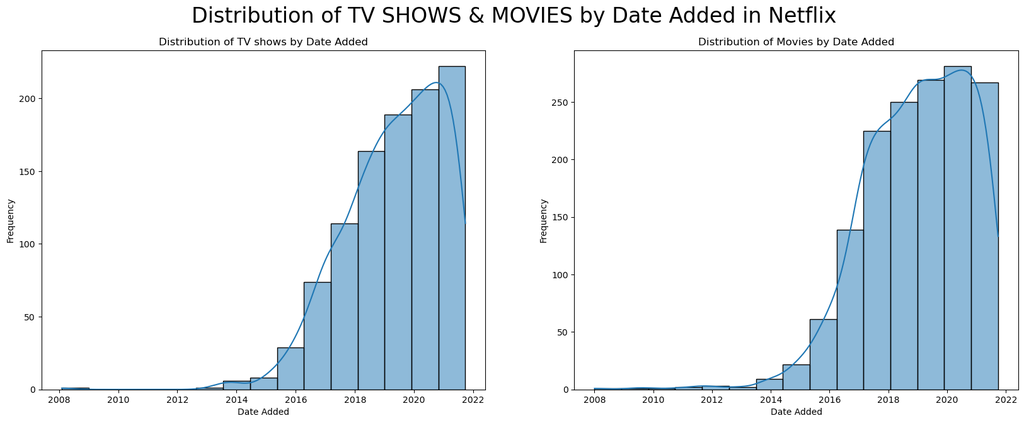

```python
plt.figure(figsize=(20, 7))
plt.subplot(1, 2, 1)
sns.histplot(df_t_d['date_added'], bins=15, kde=True)
plt.title('Distribution of TV shows by Date Added')
plt.xlabel('Date Added')
plt.ylabel('Frequency')

plt.subplot(1, 2, 2)
sns.histplot(df_m_d['date_added'], bins=15, kde=True)
plt.title('Distribution of Movies by Date Added')
plt.xlabel('Date Added')
plt.ylabel('Frequency')
plt.suptitle("Distribution of TV SHOWS & MOVIES by Date Added in Netflix", fontsize = 24)
plt.show()
```

# Distribution of TV SHOWS & MOVIES by Seasons & Durations

```python
df_t_dur = df_tv.groupby("duration").agg({"title":"nunique"}).reset_index()
df_t_dur.head(5)
```

|  | duration | title |
| --- | --- | --- |
| 0 | 1 | 1793 |
| 1 | 2 | 425 |
| 2 | 3 | 199 |
| 3 | 4 | 95 |
| 4 | 5 | 65 |

```python
df_mo_dur = df_movies.groupby("duration").agg({"title":"nunique"}).reset_index()
df_mo_dur.head(5)
```

|  | duration | title |
| --- | --- | --- |
| 0 | 3 | 1 |
| 1 | 5 | 1 |
| 2 | 8 | 1 |
| 3 | 9 | 1 |
| 4 | 10 | 1 |

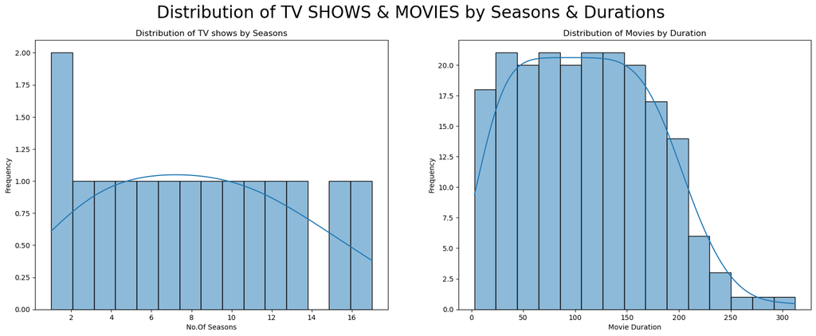

```python
plt.figure(figsize=(20, 7))
plt.subplot(1, 2, 1)
sns.histplot(df_t_dur['duration'], bins=15, kde=True)
plt.title('Distribution of TV shows by Seasons')
plt.xlabel('No.Of Seasons')
plt.ylabel('Frequency')

plt.subplot(1, 2, 2)
sns.histplot(df_mo_dur['duration'], bins=15, kde=True)
plt.title('Distribution of Movies by Duration')
plt.xlabel('Movie Duration')
plt.ylabel('Frequency')
plt.suptitle("Distribution of TV SHOWS & MOVIES by Seasons & Durations", fontsize = 24)
plt.show()
```

# Finding the Top 5 Actor & Director Pair for Movies & TV Shows

```python
cast_director_m = df_movies.groupby(["cast","director"]).agg({"title":"nunique"}).sort_values(by = ["title"], ascending=False).reset_index()
cast_director_m= cast_director_m[(cast_director_m["director"]!= "Unknown Directors") & (cast_director_m["cast"]!= "Unknown Actors") ]
cast_director_m.head(5)
```

|  | cast | director | title |
| --- | --- | --- | --- |
| 1 | Rajesh Kava | Rajiv Chilaka | 19 |
| 2 | Julie Tejwani | Rajiv Chilaka | 19 |
| 3 | Rupa Bhimani | Rajiv Chilaka | 18 |
| 4 | Jigna Bhardwaj | Rajiv Chilaka | 18 |
| 5 | Vatsal Dubey | Rajiv Chilaka | 16 |

```python
cast_director_t = df_tv.groupby(["cast","director"]).agg({"title":"nunique"}).sort_values(by = ["title"], ascending=False).reset_index()
cast_director_t= cast_director_t[(cast_director_t["director"]!= "Unknown Directors") & (cast_director_t["cast"]!= "Unknown Actors") ]

cast_director_t.head(5)
```

|  | cast | director | title |
| --- | --- | --- | --- |
| 796 | David Attenborough | Alastair Fothergill | 3 |
| 971 | Dave Chappelle | Stan Lathan | 2 |
| 1653 | Sung Dong-il | Shin Won-ho | 2 |
| 1797 | Gautham Vasudev Menon | Gautham Vasudev Menon | 2 |
| 1846 | Anjali | Gautham Vasudev Menon | 2 |

# Insights based on Non-Graphical and Visual Analysis

• Distribution of Netflix collection in Movies is 69.6% and in TV Shows it is 30.4%

• Netflix collection of Tv shows span from Year 1925 to 2021 and Movies spans from Year 1942 to 2021.

• TOP 5 GENRE IN MOVIES:

1. International Movies
2. Dramas
3. Comedies
4. Documentaries
5. Action & Adventure

• TOP 5 DIRECTOR IN TV SHOWS:

1. Ken Burns
2. Alastair Fothergill
3. Stan Lathan
4. Joe Berlinger
5. Hsu Fu-chun

• TOP 5 DIRECTOR IN MOVIES:

1. Rajiv Chilaka
2. Jan Suter
3. Raúl Campos
4. Suhas Kadav
5. Marcus Raboy

• TOP 5 ACTORS IN TV SHOWS:

1. Takahiro Sakurai
2. Yuki Kaji
3. Junichi Suwabe
4. Daisuke Ono
5. Ai Kayano

• TOP 5 ACTORS IN MOVIES:

1. Anupam Kher
2. Shah Rukh Khan
3. Naseeruddin Shah
4. Om Puri
5. Akshay Kumar

• TOP 5 Ratings IN TV SHOWS:

1. TV-MA
2. TV-14
3. TV-PG
4. TV-Y7
5. TV-Y

• TOP 5 Ratings IN MOVIES:

1. TV-MA
2. TV-14
3. R
4. TV-PG
5. PG-13

Most of Movies Movies fall under 60–145 Min duration Range

It is observed that Netflix is More focused in Mature rated Movies / TV shows

# Business Insights

It is known that R rating in india has very few titles (6)

93.52% of the content was added in the netfix in 5 years(2017–2021) and the rest 6.48% was added in 9 years (2008–2017)

Average Duration of Movies is nearly 106 Min and Tv shows is 2 seasons

Top 10 Genre covers 65.77% and the rest 32 Genre covers 34.23%

# Recommendation:

• In a Tech platform like Netflix, Business metrics like DAU (Daily active users), WAU (Weekly active users) & MAU (Monthly active users) are crucially important to look out for, and the comparison of Movie and TV series, Tv series would increase the watch time of users, in turn users would be more likely of renewing their subscription as well as more watch time ensures higher Ad revenues.

• As seen in the business insight, a movie has a possibility of 106 minutes of watch time against a Tv show of 2 seasons

• Say 2 seasons has around 10 episodes equates to 20 episodes with each assumed duration of 40 minutes totalling to 800 minutes

• As seen in the Business Insight, Most of the country’s content potential is yet to unfold, and many regional content is witnessed to breakthrough the popularity in recent years, so it is recommended to search for such regional content that may have the right potential to attract more users with the help of newly introduced novelty.

• It is understood that out of selective revenue models of Netflix, Ad revenue is indeed an important one

• Countries like Japan, Greece, Italy, Germany etc are known to have higher % of old people, Netflix can study the demographics of all countries to target the most optimal audience, in general it is undoubtedly the adult users that is targeted but, tailoring the content based on Demographics of country might help expand the userbase.

• Since pandemic, a boom in online education is seen (also known as zoom era), Netflix can tap into this demand and enable content for kids where entertaining education can help expand userbase under “Netflix for kids!”.

• We can interpret top Genres here as widely accepted genre and content produced under such genre would have higher probability of popularity and acceptance by the audience.

```python
df_final.to_csv("netflix_cleaned.csv", index = False)
```